# Used Car Price Prediction - India

**M505 Intro to AI and Machine Learning - Individual Project**

**Individual Project:** Building and Evaluating a Basic Machine Learning Pipeline

**Name:** Madhukeshwargouda Gurunathgouda Patil

**GH Number:** GH1049474

**Program:** MSc Data Science AI and Digital Business

**Course:** M505 Introduction to AI and Machine Learning

**Module Tutor:** Prof. Dr. Nghia Duong-Trung

**Title:** Individual Project

**Primary Topic:** Building and Evaluating a basic Machine Learning Pipeline

**Github link:** https://github.com/madhukeshwarpatil/M505C-Intro-to-AI-and-Machine-Learning

**DataSet link** https://www.kaggle.com/datasets/vrajesh0sharma7/used-car-price-prediction

Date of Submission: 18.09.2026

## 1. Introduction and Problem Statement

The prices of used cars in the pre-owned cars market need to be quoted by used-car marketplaces and used-car dealers. Most of the used-car dealers resort to manual appraisal, which is time-consuming, inconsistent and not scalable. In this project, a supervised machine learning (ML) framework has been designed to predict the expected price at which a used car can be sold in India based on characteristics of the car when it is appraised for valuation. Formulation - The problem is modeled as a supervised regression problem where the target variable is the sale_price of a used car in India, which is a continuous value. The input features of the model are a set of variables that describe the vehicle being appraised (e.g., make, model, year, mileage, type of fuel, type of transmission, type of ownership) and the listing context (e.g., city where the listing was created, whether a warranty was attached to the listing). Note that variables generated after the vehicle listing (e.g., views on the listing, reservations on the listing, bookings on the listing) are not to be included in the model (Section 4). The goal of the model is to capture the association between the input features and the target variable, not the causation.

## 2. Data Collection

The dataset Used Car Price Prediction (India) contains information of 7,400 used cars listed online, which contains 29 features. It also contains the price of each car in sale_price in INR. The content of the dataset includes information of the cars like make, model, year of model, number of previous owners and usage (in km) etc. The dataset also includes information of the listing of the cars like views, quotes, and bookings etc on different online platforms. The dataset is publicly available on Kaggle at https://www.kaggle.com/datasets/vrajesh0sharma7/used-car-price-prediction and was downloaded manually and saved as a CSV file named “used_car_price_prediction.csv” (relative path to file). It is to be used for education purposes and no explicit licence is stated for its use. It is of sufficient size, contains a mix of numeric and categorical values, contains real quality and leakage issues, it wasn’t used in lectures for the module and it’s a laptop friendly size.

```python
import numpy as np, pandas as pd
import matplotlib.pyplot as plt
from sklearn.model_selection import train_test_split, cross_val_score, GridSearchCV, learning_curve
from sklearn.pipeline import Pipeline
from sklearn.compose import ColumnTransformer
from sklearn.impute import SimpleImputer
from sklearn.preprocessing import OneHotEncoder, StandardScaler
from sklearn.linear_model import Ridge
from sklearn.ensemble import RandomForestRegressor
from sklearn.metrics import mean_absolute_error, mean_squared_error, r2_score

RANDOM_STATE = 42
df = pd.read_csv("data/used_car_price_prediction.csv")
print("Shape:", df.shape)
df.head(3)
```

```
Shape: (7400, 29)
```

|  | car_name | yr_mfr | fuel_type | kms_run | sale_price | city | times_viewed | body_type | transmission | variant | ... | total_owners | broker_quote | original_price | car_rating | ad_created_on | fitness_certificate | emi_starts_from | booking_down_pymnt | reserved | warranty_avail |
| --- | --- | --- | --- | --- | --- | --- | --- | --- | --- | --- | --- | --- | --- | --- | --- | --- | --- | --- | --- | --- | --- |
| 0 | maruti swift | 2015 | petrol | 8063 | 386399 | noida | 18715 | hatchback | manual | lxi opt | ... | 2 | 397677 | 404177.0 | great | 2021-04-04T07:09:18.583 | True | 8975 | 57960 | False | False |
| 1 | maruti alto 800 | 2016 | petrol | 23104 | 265499 | noida | 2676 | hatchback | manual | lxi | ... | 1 | 272935 | 354313.0 | great | 2021-03-22T14:07:32.833 | True | 6167 | 39825 | False | False |
| 2 | hyundai grand i10 | 2017 | petrol | 23402 | 477699 | noida | 609 | hatchback | manual | sports 1.2 vtvt | ... | 1 | 469605 | NaN | great | 2021-03-20T05:36:31.311 | True | 11096 | 71655 | False | False |

3 rows × 29 columns

## 3. Exploratory Data Analysis

```python
print("Duplicate rows:", df.duplicated().sum())
miss = df.isna().sum()
print(miss[miss > 0].sort_values(ascending=False))
df["sale_price"].describe().round(0)
```

```
Duplicate rows: 1
original_price         3280
car_availability        620
transmission            556
source                  126
body_type               103
registered_city          10
registered_state         10
car_rating                9
fitness_certificate       8
ad_created_on             1
dtype: int64
```

```
count       7400.0
mean      454889.0
std       282702.0
min            0.0
25%       281174.0
50%       382449.0
75%       540149.0
max      3866000.0
Name: sale_price, dtype: float64
```

**Observations:** There are 10 features out of 29 for which there are missing values (original_price: 44% car_availability and transmission: both approximately 8%); a single duplicate observation; and, the target feature is right-skewed with mean approximately equal to 455K and median approximately equal to 382K; minimum value of 0 (impossible, See Section 4 for details) and maximum value of approximately 38.7L (a very plausible luxury car); no class balancing/resampling is required as the target feature is continuous; MAE/RMSE/R² are the appropriate measures to use.

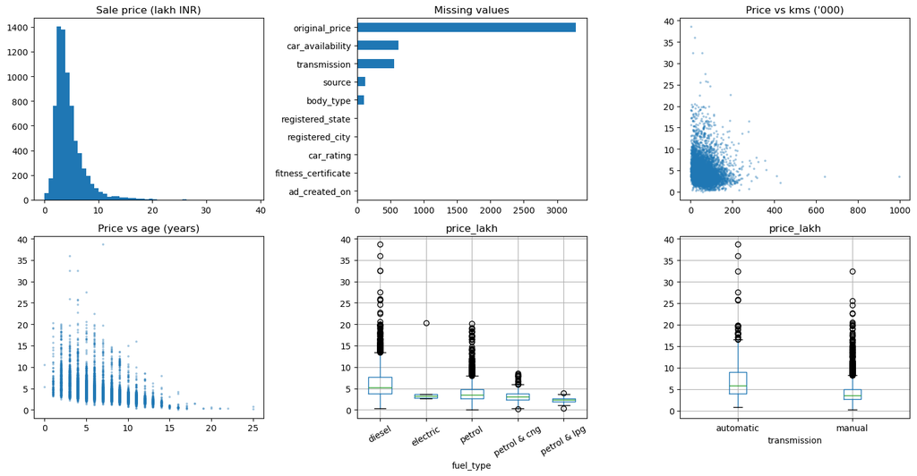

```python
d = df[df.sale_price > 0].copy()
d["price_lakh"] = d.sale_price / 1e5
d["age"] = 2021 - d.yr_mfr
fig, ax = plt.subplots(2, 3, figsize=(15, 8))
ax[0, 0].hist(d.price_lakh, bins=50)
ax[0, 0].set_title("Sale price (lakh INR)")
miss[miss > 0].sort_values().plot.barh(ax=ax[0, 1], title="Missing values")
ax[0, 2].scatter(d.kms_run / 1e3, d.price_lakh, s=3, alpha=.3)
ax[0, 2].set_title("Price vs kms ('000)")
ax[1, 0].scatter(d.age, d.price_lakh, s=3, alpha=.3)
ax[1, 0].set_title("Price vs age (years)")
d.boxplot("price_lakh", by="fuel_type", ax=ax[1, 1])
d.boxplot("price_lakh", by="transmission", ax=ax[1, 2])
ax[1, 1].tick_params(axis="x", rotation=30)
fig.suptitle("")
plt.tight_layout(); plt.show()
```

**Interpretation.** (1) Most cars sell for ₹1–8 lakh with a long luxury tail — large errors are likely on expensive cars. (2) Missing values concentrate in `original_price` and platform-status columns. (3) Price falls with mileage but noisily; one ≈997k-km reading is extreme yet possible and retained. (4) Price falls steeply and *non-linearly* with age — motivating a `vehicle_age` feature and a non-linear model. (5–6) Diesel and automatic cars have higher median prices (larger/premium vehicles) — informative categoricals.

## 4. Data Quality, Leakage and Feature Selection

**Prediction-point rule**: Feature is useful to model only if available at time car is valued (as opposed to when car is listed for sale). Suspension of disbelief regarding cell below follows.

```python
for c in ["emi_starts_from", "booking_down_pymnt", "broker_quote", "original_price"]:
    s = df[df[c] > 0].dropna(subset=[c])
    print(f"{c:20s} corr={s[c].corr(s.sale_price):.4f}  "
          f"median ratio={(s[c] / s.sale_price).median():.3f}")
```

```
emi_starts_from      corr=1.0000  median ratio=0.023
booking_down_pymnt   corr=1.0000  median ratio=0.150
broker_quote         corr=0.9864  median ratio=0.964
original_price       corr=0.9860  median ratio=1.061
```

**Exclusions** (high correlation alone is not proof — each drop has a specific reason):

[output not shown]

[output not shown]

**Invalid targets/duplicates:** I have removed three instances of price = 0 Rupees as well as one instance of 35 Rupees (impossible to price a running used car at such low figures). I have also removed a duplicate row. To ensure that the data is fair to the premium segment of vehicles, I am only keeping price instances up to 38.66 lakh Rupees.

## 5. Cleaning and Feature Engineering

`vehicle_age` = listing year – manufacture year. For prediction, we always know the ad date for a listing, so this encodes depreciation to sale for the listing’s year of manufacture rather than relying on raw `yr_mfr`. (The boolean flags encoding the categorical `is_feature` column are encoded as strings.)

```python
df = df.drop_duplicates()
df = df[df.sale_price > 10000].copy()  # removes the 4 invalid prices (0-35 INR)
ad_year = pd.to_datetime(df.ad_created_on, errors="coerce").dt.year
df["vehicle_age"] = ad_year.fillna(2021) - df.yr_mfr

num_feats = ["kms_run", "vehicle_age", "total_owners"]
cat_feats = ["fuel_type", "transmission", "body_type", "make", "model",
             "city", "assured_buy", "warranty_avail", "fitness_certificate"]
X = df[num_feats + cat_feats].copy()
for c in ["assured_buy", "warranty_avail", "fitness_certificate"]:
    X[c] = X[c].astype(str)
y = df.sale_price
print("Rows after cleaning:", len(X), "| features:", X.shape[1])
```

```
Rows after cleaning: 7395 | features: 12
```

## 6. Train–Test Split

20% held out of data for fixed reproducibility of random_state, training data used for Cross Validation and hyperparameter searching of models on held out test data which is only used once for model evaluation in Section 9. No stratification as model is a regression model, not a classification model. All learned preprocessing fitted within a pipeline on the training data only for each fold.

```python
X_train, X_test, y_train, y_test = train_test_split(
    X, y, test_size=0.2, random_state=RANDOM_STATE)
print("Train:", X_train.shape, "| Test:", X_test.shape)
```

```
Train: (5916, 12) | Test: (1479, 12)
```

## 7. Models, Pipelines and Preprocessing Strategy Comparison

**Models (meaningfully different):**

- **Ridge regression** (i.e. linear L2 regularized model): We can easily obtain signed coefficients from this model which are also meaningful. This model also assumes roughly linear effects for all variables. However, the variables are scale-sensitive.
- **Random forest** (an ensemble of decorrelated trees) - captures non-linear and interaction effects; scale-invariant but less interpretable than Ridge regression and can overfit if left unchanged and fit on full training set.

**Why pipelines:** `Pipeline` + `ColumnTransformer` in the preprocessing chain re-fit all preprocessing steps on each fold of the CV used for training (and hence no leakage) while still allowing to tune the whole chain of preprocessing steps and to replicate easily.

**Strategies** (same 5-fold CV on training data for both models — fair comparison):

- **A:** This strategy uses median imputation for missing values in numerical features most frequently and applies one-hot-encoding to features of type categorical.
- **B**: A + StandardScaler (on numerics) - showing the required effect of scaling.

```python
def preprocessor(scale):
    num_steps = [("imp", SimpleImputer(strategy="median"))]
    if scale:
        num_steps.append(("sc", StandardScaler()))
    return ColumnTransformer([
        ("num", Pipeline(num_steps), num_feats),
        ("cat", Pipeline([("imp", SimpleImputer(strategy="most_frequent")),
                          ("ohe", OneHotEncoder(handle_unknown="ignore"))]), cat_feats)])

models = {"Ridge": Ridge(),
          "RandomForest": RandomForestRegressor(random_state=RANDOM_STATE, n_jobs=-1)}
rows = []
for strat, scale in [("A: impute+OHE", False), ("B: A + scaling", True)]:
    for name, mdl in models.items():
        pipe = Pipeline([("pre", preprocessor(scale)), ("model", mdl)])
        cv = -cross_val_score(pipe, X_train, y_train, cv=5,
                              scoring="neg_mean_absolute_error", n_jobs=-1)
        rows.append({"strategy": strat, "model": name,
                     "CV MAE": cv.mean().round(0), "std": cv.std().round(0)})
base = pd.DataFrame(rows)
base
```

|  | strategy | model | CV MAE | std |
| --- | --- | --- | --- | --- |
| 0 | A: impute+OHE | Ridge | 145715.0 | 3716.0 |
| 1 | A: impute+OHE | RandomForest | 50218.0 | 1643.0 |
| 2 | B: A + scaling | Ridge | 63282.0 | 2408.0 |
| 3 | B: A + scaling | RandomForest | 50212.0 | 1664.0 |

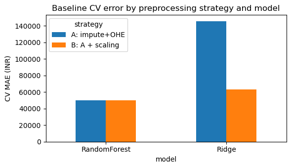

```python
base.pivot(index="model", columns="strategy", values="CV MAE").plot.bar(
    figsize=(6, 3.5), rot=0, ylabel="CV MAE (INR)",
    title="Baseline CV error by preprocessing strategy and model")
plt.tight_layout(); plt.show()
```

**Decision:** Go with Strategy B for Ridge and with Strategy A for forest. The forest is already doing better than Ridge by approximately ₹13k MAE, and matching the non-linear EDA results.

## 8. Hyperparameter Tuning (both models, 5-fold CV)

- **Ridge `alpha`**: You increase the L2 strength. It shrinks the coefficients more with higher values of alpha (more bias, less variance).
- **Forest:** The number of trees increases with reduction in variance at increased computational cost. The maximum depth of a tree can be limited by hyperparameter max_depth to prevent overfitting when set too low. Min_samples_split regulates tree splits by requiring a minimum number of cases for split at each node.

`GridSearchCV` evaluates all the values between all the hyperparameters using 5-fold CV on the training set only and uses the MAE score as the evaluation metric.

```python
gs_ridge = GridSearchCV(
    Pipeline([("pre", preprocessor(True)), ("model", Ridge())]),
    {"model__alpha": [0.01, 0.1, 1, 10, 100]},
    cv=5, scoring="neg_mean_absolute_error", n_jobs=-1).fit(X_train, y_train)
gs_rf = GridSearchCV(
    Pipeline([("pre", preprocessor(False)),
              ("model", RandomForestRegressor(random_state=RANDOM_STATE, n_jobs=-1))]),
    {"model__n_estimators": [100, 200], "model__max_depth": [None, 10, 20],
     "model__min_samples_split": [2, 5, 10]},
    cv=5, scoring="neg_mean_absolute_error", n_jobs=-1).fit(X_train, y_train)
print("Ridge best:", gs_ridge.best_params_, "| CV MAE:", round(-gs_ridge.best_score_))
print("RF best:", gs_rf.best_params_, "| CV MAE:", round(-gs_rf.best_score_))
print(pd.DataFrame({"alpha": gs_ridge.cv_results_["param_model__alpha"],
                    "CV_MAE": (-gs_ridge.cv_results_["mean_test_score"]).round(0)}).to_string(index=False))
```

```
Ridge best: {'model__alpha': 0.01} | CV MAE: 62634
RF best: {'model__max_depth': None, 'model__min_samples_split': 2, 'model__n_estimators': 200} | CV MAE: 50081
 alpha  CV_MAE
  0.01 62634.0
  0.10 62642.0
  1.00 63282.0
 10.00 69154.0
100.00 88576.0
```

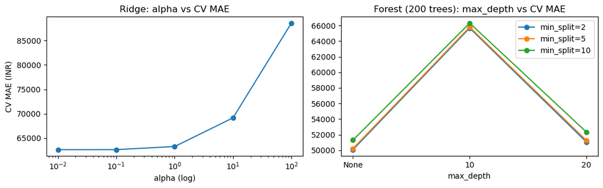

```python
fig, ax = plt.subplots(1, 2, figsize=(11, 3.5))
r = pd.DataFrame(gs_ridge.cv_results_)
ax[0].semilogx(r.param_model__alpha, -r.mean_test_score, "o-")
ax[0].set(title="Ridge: alpha vs CV MAE", xlabel="alpha (log)", ylabel="CV MAE (INR)")
f = pd.DataFrame(gs_rf.cv_results_)
f["depth"] = f.param_model__max_depth.astype(str)
for k, g in f[f.param_model__n_estimators == 200].groupby("param_model__min_samples_split"):
    ax[1].plot(g.depth, -g.mean_test_score, "o-", label=f"min_split={k}")
ax[1].set(title="Forest (200 trees): max_depth vs CV MAE", xlabel="max_depth")
ax[1].legend()
plt.tight_layout(); plt.show()
```

## 9. Final Model Selection and Test Evaluation

**Selection:** The tuned forest performs CV MAE of about ₹50.1k compared to tuned Ridge’s ₹62.6k. Selection cost here is lower interpretability. We report performance of both models on the hold-out test set **once** and report results in most business-readable form, i.e. average INR error (MAE).

**Metrics:** MAE is the average value of error in INR for each sample. MSE/RMSE is the square of large errors and hence large errors are penalized more. R² is the variance in y that our model explains vs simply predicting the mean of y.

```python
def evaluate(m, X_, y_):
    p = m.predict(X_)
    return {"MAE": mean_absolute_error(y_, p), "MSE": mean_squared_error(y_, p),
            "RMSE": np.sqrt(mean_squared_error(y_, p)), "R2": r2_score(y_, p)}

pd.DataFrame({n: evaluate(g.best_estimator_, X_test, y_test)
              for n, g in [("Ridge", gs_ridge), ("RandomForest", gs_rf)]}).T.round(3)
```

|  | MAE | MSE | RMSE | R2 |
| --- | --- | --- | --- | --- |
| Ridge | 57755.980 | 8.155418e+09 | 90307.355 | 0.890 |
| RandomForest | 46745.314 | 6.164106e+09 | 78511.823 | 0.917 |

**Interpretation.** The forest generalises well: test MAE approximately equals ₹46.7k, R² approximately equals 0.917 (Ridge approximately equals ₹57.8k / 0.890). The test MAE is even slightly smaller than the CV estimate of MAE (approximately equals ₹50.1k). No overfitting to the development data. RMSE is approximately equals ₹78.5k (~1.7× MAE) indicating that there are only a few large errors in the data. The target variable is skewed.

```
         n       MAE  MAPE_pct
band
<3L    471   32615.3      16.4
3-5L   572   32675.1       8.5
5-10L  378   68149.3      10.0
>10L    58  160757.2      11.4
       actual       pred         abs
1431  1995758  1199572.0  796185.980
5971  1800000  1165193.0  634807.465
3788  1150000   637079.0  512920.900
```

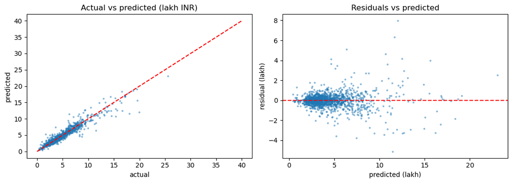

```python
best = gs_rf.best_estimator_
pred = best.predict(X_test)
resid = y_test - pred
bands = pd.cut(y_test / 1e5, [0, 3, 5, 10, 40], labels=["<3L", "3-5L", "5-10L", ">10L"])
err = pd.DataFrame({"band": bands, "abs_err": np.abs(resid),
                    "pct_err": np.abs(resid) / y_test * 100})
print(err.groupby("band", observed=True)
         .agg(n=("abs_err", "size"), MAE=("abs_err", "mean"),
              MAPE_pct=("pct_err", "mean")).round(1))
print(pd.DataFrame({"actual": y_test, "pred": pred.round(0),
                    "abs": np.abs(resid)}).nlargest(3, "abs"))
fig, ax = plt.subplots(1, 2, figsize=(11, 4))
ax[0].scatter(y_test / 1e5, pred / 1e5, s=4, alpha=.4)
ax[0].plot([0, 40], [0, 40], "r--")
ax[0].set(title="Actual vs predicted (lakh INR)", xlabel="actual", ylabel="predicted")
ax[1].scatter(pred / 1e5, resid / 1e5, s=4, alpha=.4)
ax[1].axhline(0, c="r", ls="--")
ax[1].set(title="Residuals vs predicted", xlabel="predicted (lakh)", ylabel="residual (lakh)")
plt.tight_layout(); plt.show()
```

**Error analysis.** The Printed MAE for a car priced below ₹5 lakh is approximately ₹32.6k whereas that for a car priced above ₹10 lakh is ₹160.8k. The error as a percentage is highest for the lowest priced cars (MAPE 16.4% below ₹3 lakh as opposed to 8.5% in the ₹3–5-lakh band). The predictions follow the diagonal for most of the market but start to fan out for cars priced above ~₹10 lakh. Of the largest printed errors for under-predicted cars, the worst error was for an under-predicted premium car (actual: ₹1,995,758, predicted: ₹1,199,572, error: ₹796,186). The residuals are centred and do not contain any systematic curvature i.e. error is random noise plus additional variance for premium segment, and not bias across the range of the output.

## 10. Training-Process Visualization: Learning Curve

In the absence of a loss function curve, such as for a neural network, a tree ensemble’s training process is best visualized as a learning curve – training error vs. validation error as a function of the amount of training data.

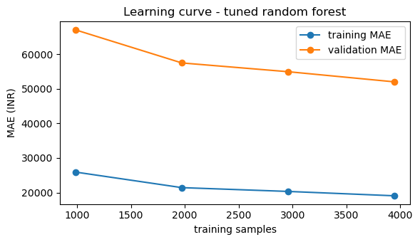

```
n=986: train MAE=25925, val MAE=67076
n=1972: train MAE=21426, val MAE=57512
n=2958: train MAE=20326, val MAE=54974
n=3944: train MAE=19065, val MAE=52037
```

```python
sizes, tr, va = learning_curve(best, X_train, y_train, cv=3,
                               train_sizes=[0.25, 0.5, 0.75, 1.0],
                               scoring="neg_mean_absolute_error", n_jobs=-1)
plt.figure(figsize=(6, 3.5))
plt.plot(sizes, -tr.mean(1), "o-", label="training MAE")
plt.plot(sizes, -va.mean(1), "o-", label="validation MAE")
plt.title("Learning curve - tuned random forest")
plt.xlabel("training samples"); plt.ylabel("MAE (INR)"); plt.legend()
plt.tight_layout(); plt.show()
for n, a, b in zip(sizes, -tr.mean(1), -va.mean(1)):
    print(f"n={int(n)}: train MAE={a:.0f}, val MAE={b:.0f}")
```

## 11. Feature Informativeness and Explainability

```
RF importances:
num__vehicle_age               0.251
cat__body_type_hatchback       0.184
cat__body_type_sedan           0.086
num__kms_run                   0.039
cat__body_type_luxury suv      0.033
cat__model_innova crysta       0.023
cat__model_eeco                0.021
cat__body_type_luxury sedan    0.020
dtype: float64
```

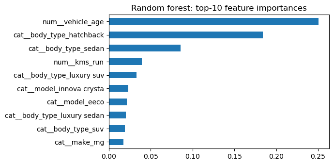

```
Ridge top |coef| (standardised):
cat__make_jaguar            1427874.0
cat__model_xj l             1427874.0
cat__model_tucson new        806012.0
cat__model_ml class          740660.0
cat__model_harrier           726250.0
cat__model_camry             724660.0
cat__model_innova crysta     704015.0
cat__model_hexa              683251.0
dtype: float64
Ridge core features:
num__kms_run                   -25714.0
num__vehicle_age              -122173.0
num__total_owners              -14078.0
cat__body_type_hatchback        -4259.0
cat__body_type_luxury sedan    128112.0
cat__body_type_luxury suv        2954.0
cat__body_type_sedan           -47642.0
cat__body_type_suv             -79165.0
dtype: float64
```

```python
imp = pd.Series(best.named_steps["model"].feature_importances_,
                index=best.named_steps["pre"].get_feature_names_out())
print("RF importances:")
print(imp.nlargest(8).round(3))
imp.nlargest(10).sort_values().plot.barh(
    figsize=(7, 3.5), title="Random forest: top-10 feature importances")
plt.tight_layout(); plt.show()
ridge = gs_ridge.best_estimator_
coef = pd.Series(ridge.named_steps["model"].coef_,
                 index=ridge.named_steps["pre"].get_feature_names_out())
print("Ridge top |coef| (standardised):")
print(coef.reindex(coef.abs().nlargest(8).index).round(0))
print("Ridge core features:")
print(coef.filter(regex="vehicle_age|kms_run|total_owners|body_type").round(0))
```

**Most informative (printed, association not causation).** Forest: vehicle_age (0.251) leads, then body-type dummies (hatchback 0.184, sedan 0.086) and then kms_run (0.039). So, age of vehicle, segment of vehicle and then mileage dominate. Ridge (standardised, INR per SD / dummy): the largest |coef| are rare premium dummies (Jaguar and xj l both +1,427,874 — identical, so collinear). Among core features, vehicle_age is largest in neg value at −122,173 followed by kms_run at −25,714 (both decrease with increase in feature). The feature ‘hatchback’ is only −4,259 in neg value and is not a leading feature in Ridge model either. Since light alpha=0.01 is used, one-hot encoding fragments make/model are inflated in rarity also. Hence, feature importances from forest feature informativeness ranking table are more stable and are shown. Note: impurity scores favor continuous features, age and mileage share credit for being important features and one-hot encoding creates fragments of make/model features.

**Explainability**: Partial. The sign of Ridge coefficient for the three features of interest (i.e. age and mileage) is readable. The large absolute values of the rare-dummy coefficients however are not stable enough to be of practical use. The extra cost of Ridge for this problem is about ₹11,000. 200 deep trees are not human-traceable for a single car.

## 12. Business Implications, Strengths, Limitations and Deployment

**Business meaning** The average error is ≈ ₹46.7k on a median value of ≈ ₹3.8-lakh car which translates to ≈12% of the price for average-size car and ≈8.5% of the price for cars in ₹3–5-lakh band. It can be used as decision support for first-pass quotes, for check by human appraiser and for identifying mispriced used cars. However, for premium used cars errors can be in several lakh and hence one should show a range (e.g. ± MAE) instead of fixed number.

**Limitations:** We use listings from 2019–21 for 13 Indian cities. Prices for these used cars have drifted. Prices for used cars from other locations will not transfer. No condition, service-history, or accident data was available. The detail in the field variant was discarded. We have no way of estimating uncertainty in our point predictions. The target variable is severely skewed and thus was not log transformed (a simple additional experiment).

**For deployment?** Not yet. First validate performance on current listings, monitor drift, retrain from time to time. Send high-value cars (> ₹10 lakh) to human appraisers. Use this to provide a suggested price range within the listing workflow.

## 13. Conclusion

The main steps of the data-audit were (1) choosing a prediction point, (2) removing 4 impossible prices, 1 duplicate, as well as all target-derived and post-listing variables. For Ridge scaling was crucial while for the forest it was irrelevant. The deepest tuning worked best, and the resulting random forest had a test MAE of ≈ ₹46.7k, a test RMSE of ≈ ₹78.5k, and a test R² of ≈ 0.917. This corresponds well with the CV estimate. The most important features were age, body type, mileage, and brand/model identity. In terms of lessons learned, leakage discipline and data preprocessing are more important than model complexity. Future work includes log-target, gradient boosting, prediction intervals for listing prices, as well as a possibly more in-depth analysis of condition data and a larger set of fresh listings.

## 14. References

- Breiman, L. (2001) 'Random forests', *Machine Learning*, 45(1), pp. 5-32.
- Hoerl, A.E. and Kennard, R.W. (1970) 'Ridge regression: biased estimation for nonorthogonal problems', *Technometrics*, 12(1), pp. 55-67.
- Pedregosa, F. et al. (2011) 'Scikit-learn: machine learning in Python', *Journal of Machine Learning Research*, 12, pp. 2825-2830.
- Scikit-learn developers (2026) *scikit-learn user guide*. Available at: https://scikit-learn.org/stable/user_guide.html (Accessed: 16 September 2026).
- Sharma, V. (2021) *Used car price prediction* [Dataset]. Kaggle. Available at: https://www.kaggle.com/datasets/vrajesh0sharma7/used-car-price-prediction (Accessed: 16 September 2026).